# Same test results, different advice

DV Assignment 2, Part 2 (first draft): school disadvantage and secondary-school advice

Group 4: Sander van Nieuwenhuijzen, Natasha Medved, Sophie Preysing

*Research Question*: Do schools with similar test results give similar secondary-school advice, regardless of how disadvantaged their student population is?

*Hypotheses*: - H1: At the same test results, schools with more disadvantaged pupils (a higher schoolweging) advise a smaller share of pupils to HAVO or higher. (The main effect between schoolweging and advice controlling for test results) - H2: This gap depends on test results: the difference between advantaged and disadvantaged schools is larger at higher test results. (The interaction effect between test results and schoolweging)

*Model*: pct_havo_plus ~ score_c * schoolweging_c + provider, weighted by n_advised - pct_havo_plus : % of pupils per school with a HAVO, HAVO/VWO or VWO advice, out of all pupils with a PRO-VWO advice (outcome) - score_c : centered average % reaching target level (3 subjects) - schoolweging_c : centered schoolweging (moderator) - provider : control, because tests differ in how often pupils reach the target level

Uses the cleaned data from 03-clean-data.R

*Reasoning behind variables for the report*:

*Score*: We use the average % of pupils reaching the target level in maths, reading and language. All three subjects declined with schoolweging in a similar way in our exploration, and they correlate moderately at school level (r = 0.57–0.68), so the average is a more stable measure of overall performance than a single subject.

*Provider as control*: Schools using different tests have similar populations, but the share of pupils reaching the target level differs strongly between tests. The same score therefore means something different per test, and so may the advice that follows from it. A school using an “easier” test can have a high score but give relatively less HAVO+ advice, simply because its teachers know the score overstates their pupils’ level. To avoid mistaking such test differences for an advice gap, we control for provider and compare schools with the same score on the same test.

*Schoolweging as moderator*: Our exploration suggested that more disadvantaged schools give less HAVO+ advice than their results predict, and more advantaged schools more. The model tests whether this holds (H1: level difference) and whether advice follows results more or less closely depending on schoolweging (H2: interaction).

*Point size*: Point size shows the number of pupils with an advice; percentages of small schools are less reliable, which is also why the model is weighted by school size.

*Why % HAVO-or-higher advice instead of an average advice score*: We summarise each school’s advice as the percentage of pupils with a HAVO, HAVO/VWO or VWO advice, rather than an average on a 1–6 scale (PRO = 1, …, VWO = 6). A percentage is easier for policymakers to interpret, needs only one cut-off instead of assuming equal distances between tracks, and captures the most consequential boundary: HAVO largely determines access to higher education.

*Why we center score and schoolweging*: Because the model includes an interaction, each main effect is estimated where the other variable is zero, which is meaningless here (no school has a schoolweging or score of 0). We therefore center both variables on their mean, so the schoolweging coefficient shows the difference in HAVO+ advice for a school with average test results. Centering does not change the model’s fit or predictions.

# 1. Load and prepare data

```r
library(cowplot)
library(tidyverse)
# Cleaned data (created by scripts/03-clean-data.R)
school_rq3 <- readRDS(here::here("data", "processed", "school_rq3.rds"))

# Centre score and schoolweging; LIB (largest provider) as reference
model_data <- school_rq3 |>
  mutate(
    score_c = score - mean(score),
    schoolweging_c = schoolweging - mean(schoolweging),
    provider = relevel(factor(provider), ref = "LIB")
  )

# Number of schools per provider
count(model_data, provider, sort = TRUE)
```

```
## # A tibble: 6 × 2
##   provider     n
##   <fct>    <int>
## 1 LIB       2683
## 2 IEP       2311
## 3 ROUTE8     333
## 4 DIA        296
## 5 AMN         64
## 6 DOE         31
```

```r
# Provider groups differ strongly in size (LIB: n = 2683, IEP: n = 2311,
# Route 8: n = 333, DIA: n = 296, AMN: n = 64, DOE: n = 31), so estimates
# for the smaller providers are less precise. We keep all providers:
# provider is only a control variable and its coefficients are not
# interpreted, so this does not affect our conclusions.
```

#2. Fit the model:

```r
# Weighted by n_advised: percentages of larger schools are more reliable

rq3_model <- lm(pct_havo_plus ~ score_c + schoolweging_c + provider + score_c*schoolweging_c, data = model_data, weights = n_advised)

summary(rq3_model)
```

```
##
## Call:
## lm(formula = pct_havo_plus ~ score_c + schoolweging_c + provider +
##     score_c * schoolweging_c, data = model_data, weights = n_advised)
##
## Weighted Residuals:
##      Min       1Q   Median       3Q      Max
## -212.933  -36.515   -3.288   30.429  264.491
##
## Coefficients:
##                         Estimate Std. Error t value Pr(>|t|)
## (Intercept)            43.799313   0.197851 221.375  < 2e-16 ***
## score_c                 0.581722   0.011356  51.227  < 2e-16 ***
## schoolweging_c         -1.758167   0.041985 -41.876  < 2e-16 ***
## providerAMN            -3.859264   1.213109  -3.181 0.001474 **
## providerDIA             2.014497   0.605976   3.324 0.000892 ***
## providerDOE             1.311277   1.568893   0.836 0.403304
## providerIEP             2.206660   0.274410   8.041 1.07e-15 ***
## providerROUTE8          0.259053   0.576875   0.449 0.653404
## score_c:schoolweging_c -0.032585   0.002152 -15.139  < 2e-16 ***
## ---
## Signif. codes:  0 '***' 0.001 '**' 0.01 '*' 0.05 '.' 0.1 ' ' 1
##
## Residual standard error: 52.31 on 5709 degrees of freedom
## Multiple R-squared:  0.6645, Adjusted R-squared:  0.664
## F-statistic:  1413 on 8 and 5709 DF,  p-value: < 2.2e-16
```

```r
# Results (same test provider, LIB as reference; R-squared = 0.66):
#   - score_c (0.58): 1 percentage point (pp) higher score -> 0.58 pp more HAVO+ advice,
#     at average schoolweging
#   - schoolweging_c (-1.76): 1 point more disadvantaged -> 1.76 pp less
#     HAVO+ advice, at the same (average) test results
#   - interaction (-0.033): the score-advice slope is weaker in more
#     disadvantaged schools
# All p < 0.001. Not causal: shows that advice differs, not why.

confint(rq3_model) #95% confidence intervals
```

```
##                              2.5 %      97.5 %
## (Intercept)            43.41144985 44.18717686
## score_c                 0.55946050  0.60398362
## schoolweging_c         -1.84047285 -1.67586040
## providerAMN            -6.23741695 -1.48111051
## providerDIA             0.82655483  3.20243935
## providerDOE            -1.76434923  4.38690404
## providerIEP             1.66871247  2.74460660
## providerROUTE8         -0.87184094  1.38994676
## score_c:schoolweging_c -0.03680456 -0.02836536
```

*Test results (score)* When controlling for test provider and holding schoolweging at its average, there is a positive relationship between test results and HAVO+ advice: schools where a higher percentage of pupils reaches the target level give a higher share of HAVO+ advice. Each percentage point (pp) higher score goes with 0.58 pp more HAVO+ advice (95% CI: 0.56 to 0.60, p < 0.001).

*Schoolweging* There is a negative relationship between schoolweging and HAVO+ advice, at the same (average) test results and the same test provider: the more disadvantaged a school’s student population, the smaller the share of pupils that gets HAVO+ advice. Each point higher schoolweging goes with 1.76 pp less HAVO+ advice (95% CI: −1.84 to −1.68, p < 0.001), so two schools with the same results but 10 points apart in schoolweging differ by about 18 pp (95% CI: 17 to 18 pp). This supports H1.

*Interaction* The interaction is significant (−0.033, 95% CI: −0.037 to −0.028, p < 0.001): for every point increase in schoolweging (a more disadvantaged school), the positive relationship between test results and HAVO+ advice becomes 0.033 weaker. In other words, higher test results translate less into HAVO+ advice in more disadvantaged schools, so the gap between advantaged and disadvantaged schools is largest among high-scoring schools. This supports H2.

*Intercept and model fit* With LIB as the reference provider, the intercept (43.8%, 95% CI: 43.4 to 44.2) is the predicted share of HAVO+ advice for a LIB school with average test results and average schoolweging. Together, test results, schoolweging and provider explain about two thirds of the variation in HAVO+ advice between schools (R² = 0.66).

*Interpretation* These results are not causal: they show that schools with similar test results but more disadvantaged pupils give less HAVO+ advice, but not why, for example whether this reflects teachers’ expectations or information about pupils that the test does not capture.

# Predicted lines at 10th, 50th and 90th quantile:

```r
# geom_smooth() cannot draw trend lines (based on predictions) from our
# own model. So we let the model predict % HAVO+ advice across all scores,
# for a LIB school, at low, medium and high schoolweging,
# and plot those predictions. This keeps the plot and the model equal.

# 1. The three schoolweging values for the lines (10th, 50th, 90th pct)
sw_levels <- quantile(model_data$schoolweging, c(0.1, 0.5, 0.9))

# 2. All combinations of 100 scores and the 3 schoolweging values,
#    for a LIB school (the most common provider)
pred_grid <- expand_grid(
  score = seq(min(model_data$score), max(model_data$score),
              length.out = 100),
  schoolweging = sw_levels
) |>
  mutate(
    score_c = score - mean(model_data$score),
    schoolweging_c = schoolweging - mean(model_data$schoolweging),
    provider = "LIB"
  )

# 3. Ask the model for the predicted % HAVO+ (fit) and its 95% CI
pred_grid <- bind_cols(
  pred_grid,
  as_tibble(predict(rq3_model, newdata = pred_grid, interval = "confidence"))
)
```

#4. Size of the gap at an average score

```r
# Both schools have the same (average) % reaching the target level and use
# LIB; only their schoolweging differs (10th pct: advantaged vs
# 90th pct: disadvantaged). The arrow shows
# the difference in their predicted % HAVO+ advice.

# Predicted HAVO+ at the average score, for the 10th and 90th percentile
gap_data <- tibble(schoolweging = unname(sw_levels[c(1, 3)])) |>
  mutate(
    score = mean(model_data$score),
    score_c = 0,
    schoolweging_c = schoolweging - mean(model_data$schoolweging),
    provider = factor("LIB", levels = levels(model_data$provider))
  )
gap_data$fit <- predict(rq3_model, newdata = gap_data)

gap_size <- round(gap_data$fit[1] - gap_data$fit[2], 1)
gap_size # percentage points less HAVO+ advice in more disadvantaged schools
```

```
##    1
## 16.9
```

#5. Final plot:

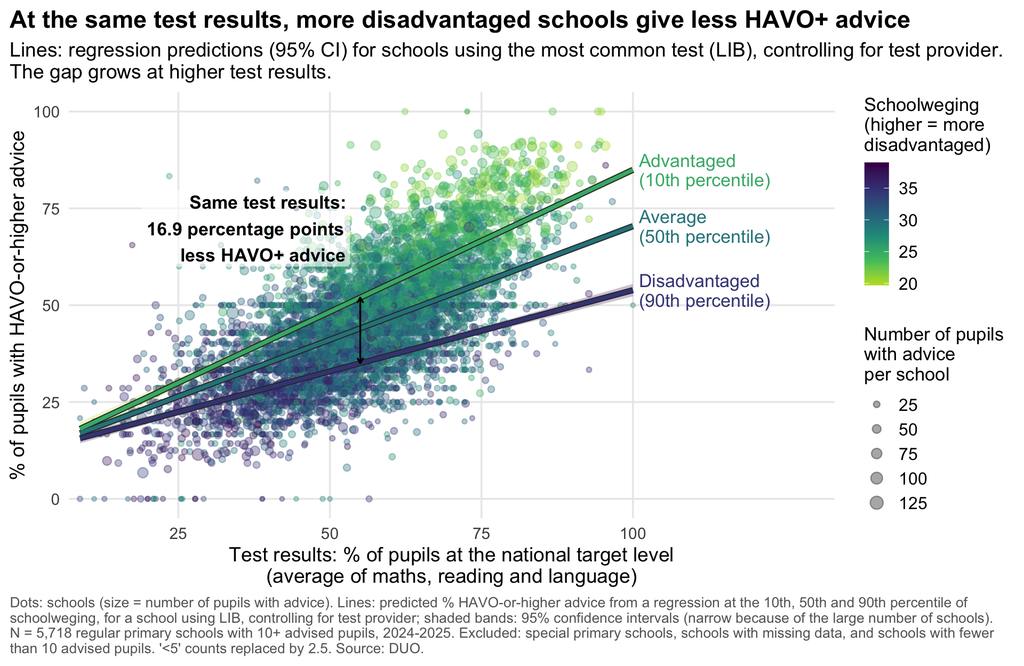

```r
#Line labels:
line_labels <- pred_grid |>
  filter(score == max(score)) |>
  mutate(
    label = c(
      "Advantaged\n(10th percentile)",
      "Average\n(50th percentile)",
      "Disadvantaged\n(90th percentile)"
    )[match(schoolweging, sw_levels)]
  )

# Although the trend lines are drawn for a LIB school, the model and the
# points in the plot include all schools and all providers, with provider
# as a control variable. To make predictions, every variable needs a
# value, so we use LIB (the most common test). Provider only shifts all
# lines up or down by the same amount, so their shape and the gap between
# them are the same for every test.

final_plot <- ggplot() +
  # Schools: colour = schoolweging, size = pupils with an advice
  geom_point(
    data = model_data,
    aes(
      x = score, y = pct_havo_plus,
      colour = schoolweging, size = n_advised
    ),
    alpha = 0.35
  ) +
  # Confidence bands of the model lines
  geom_ribbon(
    data = pred_grid,
    aes(
      x = score, ymin = lwr, ymax = upr,
      fill = schoolweging, group = schoolweging
    ),
    alpha = 0.25
  ) +
  # Dark outline under each line
  geom_line(
    data = pred_grid,
    aes(x = score, y = fit, group = schoolweging),
    colour = "grey20", linewidth = 2
  ) +
  # Model-predicted lines at the 10th, 50th and 90th percentile
  geom_line(
    data = pred_grid,
    aes(x = score, y = fit, colour = schoolweging, group = schoolweging),
    linewidth = 1.3
  ) +
  # Direct labels at the end of each line
  geom_text(
    data = line_labels,
    aes(x = score, y = fit, label = label, colour = schoolweging),
    hjust = 0, nudge_x = 1, size = 4.5, lineheight = 0.9
  ) +
  # The gap at an average score
  annotate(
    "segment",
    x = mean(model_data$score), xend = mean(model_data$score),
    y = gap_data$fit[2], yend = gap_data$fit[1],
    arrow = arrow(ends = "both", length = unit(0.15, "cm")),
    linewidth = 0.6
  ) +
  annotate(
    "label",
    x = mean(model_data$score), y = max(gap_data$fit) + 8,
    label = paste0(
      "Same test results:\n", gap_size,
      " percentage points\nless HAVO+ advice"
    ),
    hjust = 1.05, vjust = 0, size = 4.5, linewidth = 0,
    fill = alpha("white", 0.6), fontface = "bold"
  ) +
  scale_colour_viridis_c(
    name = "Schoolweging\n(higher = more\ndisadvantaged)",
    direction = -1, end = 0.9
  ) +
  scale_fill_viridis_c(direction = -1, end = 0.9, guide = "none") +
  scale_size_area(
    name = "Number of pupils\nwith advice\nper school",
    max_size = 4,
    breaks = c(25, 50, 75, 100, 125)
  ) +
  scale_x_continuous(
    breaks = seq(0, 100, by = 25),
    expand = expansion(mult = c(0.02, 0.35))
  ) +
  scale_y_continuous(limits = c(0, 100)) +
  coord_cartesian(clip = "off") +
  labs(
    title = paste(
      "At the same test results, more disadvantaged schools give",
      "less HAVO+ advice"
    ),
    subtitle = paste0(
      "Lines: regression predictions (95% CI) for schools using the most ",
      "common test (LIB), controlling for test provider. ",
      "\nThe gap grows at higher test results."
    ),
    x = "Test results: % of pupils at the national target level\n(average of maths, reading and language)",
    # x = "Test results: % of pupils reaching target level", <- other suggestion
    # x = "Average % of pupils reaching the target level (3 subjects)", <- original
    y = "% of pupils with HAVO-or-higher advice",
    caption = paste0(
      "Dots: schools (size = number of pupils with advice). Lines: predicted ",
      "% HAVO-or-higher advice from a regression at the 10th, 50th and 90th ",
      "percentile of \nschoolweging, for a school using LIB, controlling for ",
      "test provider; shaded bands: 95% confidence intervals (narrow because ",
      "of the large number of schools).\nN = ",
      format(nrow(model_data), big.mark = ","),
      " regular primary schools with 10+ advised pupils, 2024-2025. ",
      "Excluded: special primary schools, schools with missing data, and ",
      "schools with fewer \nthan 10 advised pupils. '<5' counts replaced by ",
      "2.5. Source: DUO."
      # add somewhere in the caption: "Target level: the higher of two national
      # reference levels ","(basic = 1F; target = 1S for maths, 2F for reading and language).\n",
    )
  ) +
  theme_minimal(base_size = 14) +
  theme(
    plot.title = element_text(face = "bold", size = 17),
    plot.subtitle = element_text(size = 14),
    plot.caption = element_text(size = 10, colour = "grey40", hjust = 0),
    plot.title.position = "plot",
    plot.caption.position = "plot",
    legend.title = element_text(size = 13),
    legend.text = element_text(size = 12),
    panel.grid.minor = element_blank()
  )

final_plot
```

# Version 2:

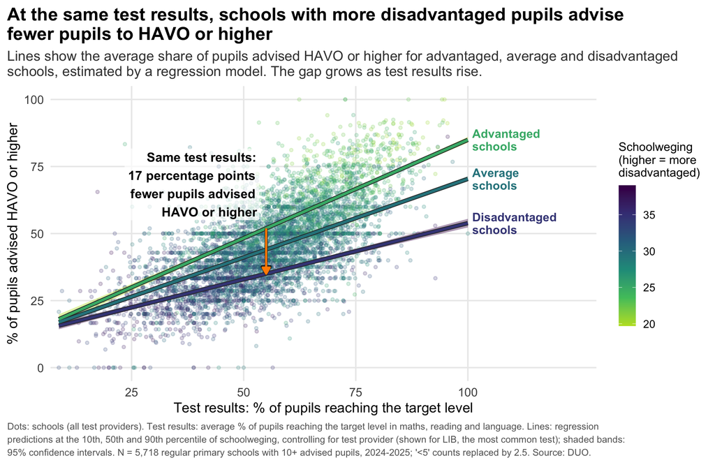

```r
line_labels <- pred_grid |>
  filter(score == max(score)) |>
  mutate(
    label = c(
      "Advantaged\nschools",
      "Average\nschools",
      "Disadvantaged\nschools"
    )[match(schoolweging, sw_levels)]
  )

final_plot2 <- ggplot() +
  # Schools (all providers)
  geom_point(
    data = model_data,
    aes(x = score, y = pct_havo_plus, colour = schoolweging),
    size = 1.2, alpha = 0.2
  ) +
  # Uncertainty bands of the lines
  geom_ribbon(
    data = pred_grid,
    aes(
      x = score, ymin = lwr, ymax = upr,
      fill = schoolweging, group = schoolweging
    ),
    alpha = 0.4
  ) +
  # Dark outline under each line
  geom_line(
    data = pred_grid,
    aes(x = score, y = fit, group = schoolweging),
    colour = "grey20", linewidth = 2
  ) +
  # Expected advice at three levels of disadvantage
  geom_line(
    data = pred_grid,
    aes(x = score, y = fit, colour = schoolweging, group = schoolweging),
    linewidth = 1.3
  ) +
  # Line labels
  geom_text(
    data = line_labels,
    aes(x = score, y = fit, label = label, colour = schoolweging),
    hjust = 0, nudge_x = 1, size = 4.2, lineheight = 0.9,
    fontface = "bold"
  ) +
  # Gap arrow:
  annotate(
    "segment",
    x = mean(model_data$score), xend = mean(model_data$score),
    y = gap_data$fit[1], yend = gap_data$fit[2],
    arrow = arrow(ends = "last", length = unit(0.29, "cm"), type = "closed"),
    colour = "grey15", linewidth = 1.4
  ) +
  annotate(
    "segment",
    x = mean(model_data$score), xend = mean(model_data$score),
    y = gap_data$fit[1], yend = gap_data$fit[2],
    arrow = arrow(ends = "last", length = unit(0.25, "cm"), type = "closed"),
    colour = "#FF8C00", linewidth = 1
  ) +
  annotate(
    "label",
    x = mean(model_data$score), y = max(gap_data$fit) + 3,
    label = paste0(
      "Same test results:\n", round(gap_size), " percentage points\n",
      "fewer pupils advised\nHAVO or higher"
    ),
    hjust = 1.05, vjust = 0, size = 4.5, linewidth = 0,
    fill = alpha("white", 0.7), fontface = "bold"
  ) +
  scale_colour_viridis_c(
    name = "Schoolweging\n(higher = more\ndisadvantaged)",
    breaks = c(20, 25, 30, 35),
    direction = -1, end = 0.9,
    guide = guide_colourbar(barheight = unit(5, "cm"))
  ) +
  scale_fill_viridis_c(direction = -1, end = 0.9, guide = "none") +
  scale_x_continuous(
    breaks = seq(0, 100, by = 25),
    expand = expansion(mult = c(0.02, 0.3))
  ) +
  scale_y_continuous(limits = c(0, 100)) +
  coord_cartesian(clip = "off") +
  labs(
    title = paste(
      "At the same test results, schools with more disadvantaged pupils",
      "advise\nfewer pupils to HAVO or higher"
    ),
    subtitle = paste0(
  "Lines show the average share of pupils advised HAVO or higher for ",
  "advantaged, average and disadvantaged \nschools, estimated by a ",
  "regression model. The gap grows as test results rise."
    ),
    x = "Test results: % of pupils reaching the target level",
    y = "% of pupils advised HAVO or higher",
    caption = paste0(
      "Dots: schools (all test providers). Test results: average % of ",
      "pupils reaching the target level in maths, reading and language. ",
      "Lines: regression\npredictions at the 10th, 50th and 90th ",
      "percentile of schoolweging, controlling for test provider (shown ",
      "for LIB, the most common test); shaded bands:\n95% confidence ",
      "intervals. N = ", format(nrow(model_data), big.mark = ","),
      " regular primary schools with 10+ advised pupils, 2024-2025; ",
      "'<5' counts replaced by 2.5. Source: DUO."
    )
  ) +
  theme_minimal(base_size = 15) +
  theme(
    plot.title = element_text(face = "bold", size = 18),
    plot.subtitle = element_text(size = 14, colour = "grey25"),
    plot.caption = element_text(
      size = 9.5, colour = "grey40", hjust = 0, lineheight = 1.15
    ),
    plot.title.position = "plot",
    plot.caption.position = "plot",
    axis.title = element_text(size = 14),
    axis.text = element_text(size = 12),
    legend.title = element_text(size = 12),
    legend.text = element_text(size = 11),
    panel.grid.minor = element_blank()
  )

final_plot2
```

#6. Robustness Checks (do not forget changing 2.5 -> 1, 2.5 -> 4)

```r
#Maths only model:
rob1_model_data <- model_data |>
  mutate(maths_c = pct_maths_1s - mean(pct_maths_1s))

rob1_model <- lm(pct_havo_plus ~ maths_c + schoolweging_c + provider + maths_c*schoolweging_c,
    data = rob1_model_data, weights = n_advised)


#Advice average model:
rob2_model <- lm(avg_advice ~ score_c + schoolweging_c + provider + score_c*schoolweging_c, data = model_data, weights = n_advised)


#Model without AMN and DOE (small sample size)
rob3_model_data <- model_data |>
  filter(!provider %in% c("DOE", "AMN")) |>
  droplevels()


rob3_model <- lm(pct_havo_plus ~ score_c + schoolweging_c + provider + score_c*schoolweging_c, data = rob3_model_data, weights = n_advised)

# Schoolweging effect and interaction (estimate and p-value) per model
get_effect <- function(model, a) {
  coefs <- coef(summary(model))
  tibble(
    "schoolweging estimate" = coefs["schoolweging_c", "Estimate"],
    "schoolweging p-value" = coefs["schoolweging_c", "Pr(>|t|)"],
    "interaction estimate" = coefs[a, "Estimate"],
    "interaction p-value" = coefs[a, "Pr(>|t|)"]
  )
}

robustness <- bind_rows(
  "Main model" = get_effect(rq3_model, "score_c:schoolweging_c"),
  "Maths only" = get_effect(rob1_model, "maths_c:schoolweging_c"),
  "Average advice (1-6)" = get_effect(rob2_model, "score_c:schoolweging_c"),
  "Without AMN and DOE" = get_effect(rob3_model, "score_c:schoolweging_c"),
  .id = "model"
)

robustness
```

```
## # A tibble: 4 × 5
##   model     schoolweging estimat…¹ `schoolweging p-value` `interaction estimate`
##   <chr>                      <dbl>                  <dbl>                  <dbl>
## 1 Main mod…                -1.76                        0              -0.0326
## 2 Maths on…                -2.10                        0              -0.0183
## 3 Average …                -0.0530                      0              -0.000360
## 4 Without …                -1.76                        0              -0.0326
## # ℹ abbreviated name: ¹`schoolweging estimate`
## # ℹ 1 more variable: `interaction p-value` <dbl>
```

```r
#all results are robust
```

The results are robust. The negative schoolweging effect and the negative interaction remain significant (all p < 0.001) when using maths results only (−2.10 pp per point of schoolweging), when excluding the two smallest providers (−1.76 pp, practically unchanged), and when measuring advice as the average on a 1–6 scale (−0.05 per point, i.e. about half a track lower advice for a 10-point difference in schoolweging).